# Modelo VAR

Francisco Yorio

2023-05-01

### Instalación de Paquetes:

Para instalar todas las librerias (remover ‘#’)

```r
#install.packages(c("readxl", "tidyverse", "lubridate", "car", "urca", "tseries", "astsa", "forecast", "foreign", "timsac", "vars", "mFilter", "dynlm", "nlme", "strucchange", "quantmod", "xts", "Hmisc", "scales"))
```

Para cargar librerías

```r
library(readxl)
library(ggplot2)
library(tidyverse)
library(lubridate)
library(car)
library(urca)
library(tseries)
library(astsa)
library(forecast)
library(foreign)
library(timsac)
library(vars)
library(mFilter)
library(dynlm)
library(nlme)
library(strucchange)
library(quantmod)
library(xts)
library(scales)
```

# Revisión y Transformación de data

## Carga de datos

Primero Fije su directorio de trabajo (recuerde reemplzar por la ruta de su carpeta)

[**Truco:** Puede correr en consola la función “file.choose()”, esto le permitirá seleccionar un archivo de su carpeta de trabajo, y le entregará en la consola la ruta de ese archivo, luego, puede copiar, pegar y simplemente remover el nombre del archivo, y almacenar solo el nombre de la carpeta (esto almacenará la ruta con doble slashs inversos)]

```r
setwd("C:\\Users\\fyorio\\OneDrive - Quantia\\Quantia\\Presentaciones\\Series de tiempo")
```

Cargue el set de datos (ya debe tener el archivo en su carpeta)

```r
datos <- read_excel("Base_VAR_1996_2022.xlsx", sheet = "SinVariaciones")
```

## Especificación de serie temporal

```r
datos <- ts(datos, start = 1996, frequency = 4)
```

## Visualización de variables

Note que aquí no guardo el archivo en una imagen jpg como en el ejemplo, y adicionalmente, cambié algunos parámetros de la función par para mejorar la visualización.

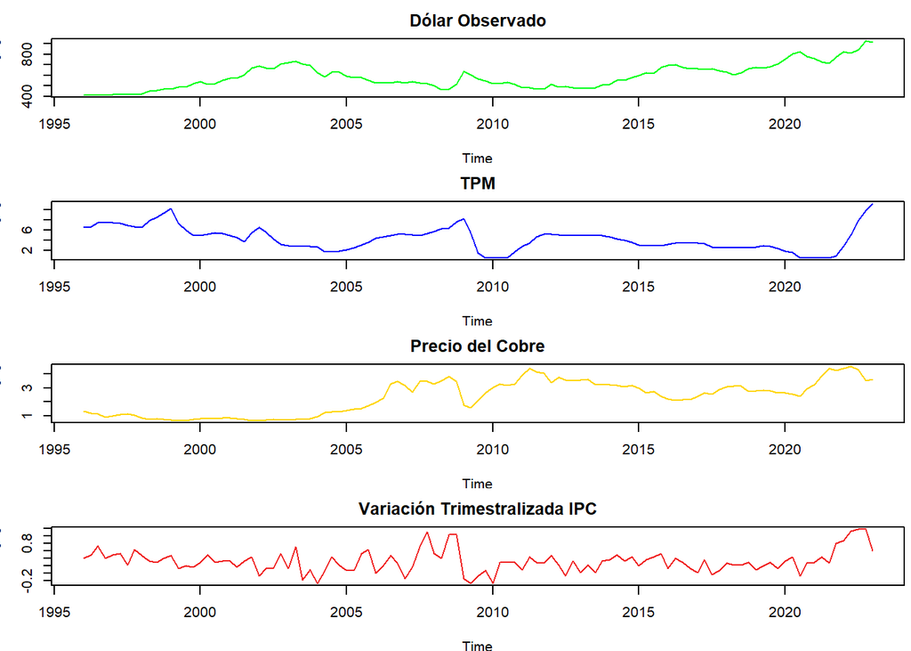

```r
colores <- c("#00ff1a", "blue", "#ffd500", "#f02020")
titulos <- c("Dólar Observado", "TPM", "Precio del Cobre", "Variación Trimestralizada IPC")

# Aumenta los valores de 'pin' para cambiar el tamaño del gráfico
# Ajusta los valores de 'mai' para cambiar los márgenes alrededor de los gráficos
par(mfrow = c(4, 1), mar = c(4, 4, 4, 2) + 0.1, pch = 20, pin = c(15, 10), plt = c(0.1, 0.9, 0.1, 0.9), mai = c(0.5, 0.4, 0.3, 0.05))

for (i in 1:ncol(datos)) {
  plot(datos[, i], type = "l", col = colores[i], main = titulos[i])
}
```

## Definición de variables individuales

```r
dolar_obs = ts(datos[,1], start=1996, freq=4)
TPM = ts(datos[,2], start=1996, freq=4)
prec_cobre = ts(datos[,3], start=1996, freq=4)
IPC = ts(datos[,4], start=1996, freq=4)
```

# Estacionariedad

## Pruebas de Raiz Unitaria

```r
adf.test(dolar_obs, alternative = "stationary")
```

```
##
##  Augmented Dickey-Fuller Test
##
## data:  dolar_obs
## Dickey-Fuller = -1.3325, Lag order = 4, p-value = 0.8535
## alternative hypothesis: stationary
```

```r
# p-value = 0.8535
adf.test(TPM, alternative = "stationary")
```

```
##
##  Augmented Dickey-Fuller Test
##
## data:  TPM
## Dickey-Fuller = -2.6035, Lag order = 4, p-value = 0.3263
## alternative hypothesis: stationary
```

```r
# p-value = 0.3263
adf.test(prec_cobre, alternative = "stationary")
```

```
##
##  Augmented Dickey-Fuller Test
##
## data:  prec_cobre
## Dickey-Fuller = -2.5113, Lag order = 4, p-value = 0.3645
## alternative hypothesis: stationary
```

```r
# p-value = 0.3645
adf.test(IPC, alternative = "stationary")
```

```
##
##  Augmented Dickey-Fuller Test
##
## data:  IPC
## Dickey-Fuller = -3.7394, Lag order = 4, p-value = 0.02444
## alternative hypothesis: stationary
```

```r
# p-value = 0.02444
```

Función ndiffs()

```r
ndiffs(dolar_obs)
```

```
## [1] 1
```

```r
ndiffs(TPM)
```

```
## [1] 1
```

```r
ndiffs(prec_cobre)
```

```
## [1] 1
```

```r
ndiffs(IPC)
```

```
## [1] 0
```

## Diferenciación

```r
dolar_obs_diff <- diff(dolar_obs)
TPM_diff <- diff(TPM)
prec_cobre_diff <- diff(prec_cobre)
```

Ajustes de extensión

```r
# Extensiones (IPC tiene una variable más, porque no se diferenció)
length(dolar_obs_diff)
```

```
## [1] 108
```

```r
length(TPM_diff)
```

```
## [1] 108
```

```r
length(prec_cobre_diff)
```

```
## [1] 108
```

```r
length(IPC)
```

```
## [1] 109
```

```r
IPC <- tail(IPC, n = length(IPC) - 1) #Le quitamos el primer valor al IPC para que su extensión encaje con las series diferenciadas
length(IPC)
```

```
## [1] 108
```

Unión de Variables Estacionarias

```r
datos_est <- cbind(dolar_obs_diff, TPM_diff, prec_cobre_diff, IPC)
```

## Revisión Gráfica

Comportamiento de las variables estacionarias

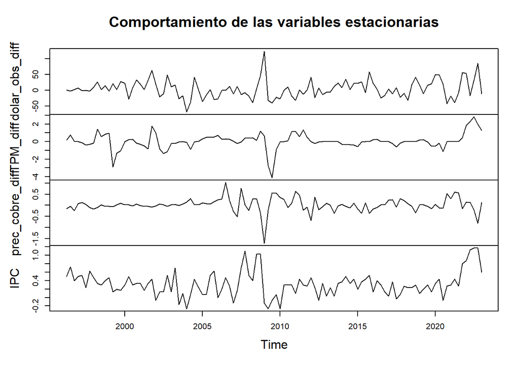

```r
plot(datos_est, main = "Comportamiento de las variables estacionarias")
```

Comparación de variables con y sin estacionariedad

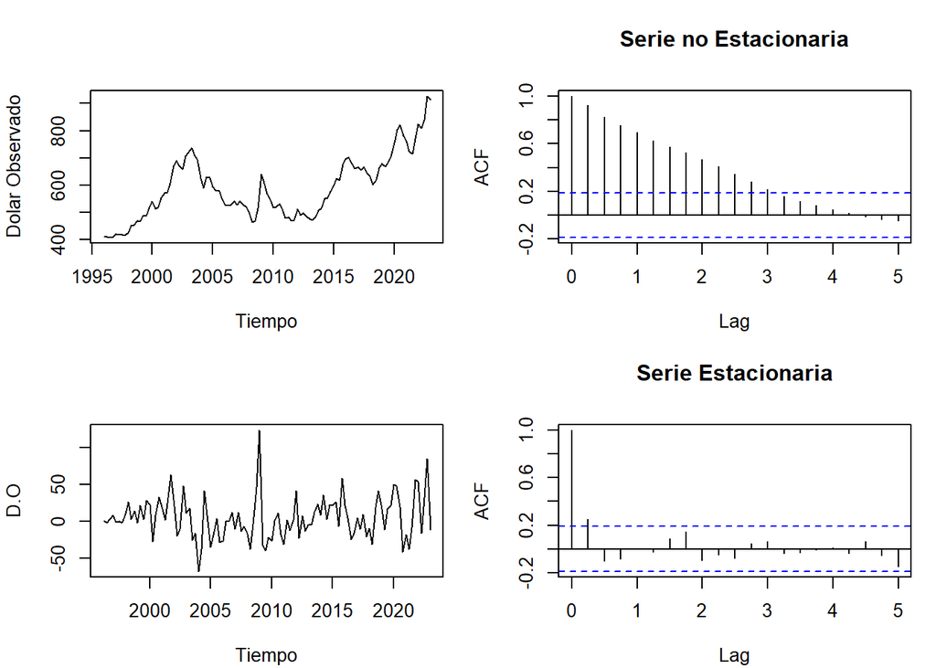

```r
par(mfrow=c(2,2), mar=c(4,4,4,1) + .1)
plot(dolar_obs, ylab="Dolar Observado", xlab="Tiempo")
acf(dolar_obs, main="Serie no Estacionaria")
plot(dolar_obs_diff, ylab="D.O", xlab="Tiempo")
acf(dolar_obs_diff, main="Serie Estacionaria")
```

## Normalización

Método de mínimos y máximos

```r
# Convertir las columnas de la serie de tiempo a objetos de clase "numeric"
datos_est_num <- apply(datos_est, 2, as.numeric)

# Normalizar los datos en un rango de 0 a 1 utilizando la función scales::rescale()
datos_norm <- apply(datos_est_num, 2, scales::rescale)

# Convertir el resultado a un dataframe
datos_norm <- as.data.frame(datos_norm)
```

Definicón de Serie temporal

```r
datos_norm_ts <- ts(datos_norm, start=1996, freq=4)
```

```r
dolar_obs_diff_norm = ts(datos_norm_ts[,1], start=1996, freq=4)
TPM_diff_norm = ts(datos_norm_ts[,2], start=1996, freq=4)
prec_cobre_diff_norm  = ts(datos_norm_ts[,3], start=1996, freq=4)
IPC_norm  = ts(datos_norm_ts[,4], start=1996, freq=4)
```

# Causalidad de Granger

## Aplicación común del test

```r
grangertest(prec_cobre_diff_norm ~ dolar_obs_diff_norm, order = 1)
```

```
## Granger causality test
##
## Model 1: prec_cobre_diff_norm ~ Lags(prec_cobre_diff_norm, 1:1) + Lags(dolar_obs_diff_norm, 1:1)
## Model 2: prec_cobre_diff_norm ~ Lags(prec_cobre_diff_norm, 1:1)
##   Res.Df Df      F  Pr(>F)
## 1    104
## 2    105 -1 5.1575 0.02521 *
## ---
## Signif. codes:  0 '***' 0.001 '**' 0.01 '*' 0.05 '.' 0.1 ' ' 1
```

## Bucle para aplicar el test secuancialmente con orden del 1 al 12.

**Truco:** Si debe volver a aplicar el test porque no encontró causalidad, puede usar un bucle for para probar automaticamente con órdenes del 1 al 12.

```r
# Crear una lista vacía para almacenar los resultados de la prueba de Granger
granger_results <- list()
# Realizar la prueba de causalidad de Granger para diferentes órdenes (1 a 12)
for (order in 1:12) {
  granger_results[[order]] <- grangertest(IPC ~ TPM_diff, order = order)
}
# Ver los resultados de la prueba de Granger
granger_results
```

```
## [[1]]
## Granger causality test
##
## Model 1: IPC ~ Lags(IPC, 1:1) + Lags(TPM_diff, 1:1)
## Model 2: IPC ~ Lags(IPC, 1:1)
##   Res.Df Df      F Pr(>F)
## 1    104
## 2    105 -1 0.9545 0.3309
##
## [[2]]
## Granger causality test
##
## Model 1: IPC ~ Lags(IPC, 1:2) + Lags(TPM_diff, 1:2)
## Model 2: IPC ~ Lags(IPC, 1:2)
##   Res.Df Df      F Pr(>F)
## 1    101
## 2    103 -2 1.3265   0.27
##
## [[3]]
## Granger causality test
##
## Model 1: IPC ~ Lags(IPC, 1:3) + Lags(TPM_diff, 1:3)
## Model 2: IPC ~ Lags(IPC, 1:3)
##   Res.Df Df      F Pr(>F)
## 1     98
## 2    101 -3 0.7217 0.5414
##
## [[4]]
## Granger causality test
##
## Model 1: IPC ~ Lags(IPC, 1:4) + Lags(TPM_diff, 1:4)
## Model 2: IPC ~ Lags(IPC, 1:4)
##   Res.Df Df      F Pr(>F)
## 1     95
## 2     99 -4 1.1075 0.3576
##
## [[5]]
## Granger causality test
##
## Model 1: IPC ~ Lags(IPC, 1:5) + Lags(TPM_diff, 1:5)
```

[output cut: 52 more lines]

```
##
## Model 1: IPC ~ Lags(IPC, 1:11) + Lags(TPM_diff, 1:11)
## Model 2: IPC ~ Lags(IPC, 1:11)
##   Res.Df  Df      F Pr(>F)
## 1     74
## 2     85 -11 1.0081 0.4478
##
## [[12]]
## Granger causality test
##
## Model 1: IPC ~ Lags(IPC, 1:12) + Lags(TPM_diff, 1:12)
## Model 2: IPC ~ Lags(IPC, 1:12)
##   Res.Df  Df      F Pr(>F)
## 1     71
## 2     83 -12 0.9283 0.5241
```

En este caso, por ejemplo, no hay causalidad en ninguno de los 12 lags.

**Recuerde que lo ideal es hacer pruebas para todas las relaciones que planea medir** En este ejemplo, solo se enseña a aplicar el test para que usted pueda replicarlo con más variables e interacciones.

## Ejemplo para aplicar rezago extra a una de las variables

```r
# Crear un dataframe con las series temporales
data <- cbind(prec_cobre_diff, dolar_obs_diff)

# Ajustar un modelo VAR personalizado
var_model <- VAR(data, p = 2, type = "const", season = NULL, exogen = NULL)

# Realizar la prueba de Granger
granger_test <- causality(var_model, cause = "dolar_obs_diff")

# Mostrar los resultados
print(granger_test)
```

```
## $Granger
##
##  Granger causality H0: dolar_obs_diff do not Granger-cause
##  prec_cobre_diff
##
## data:  VAR object var_model
## F-Test = 2.2195, df1 = 2, df2 = 202, p-value = 0.1113
##
##
## $Instant
##
##  H0: No instantaneous causality between: dolar_obs_diff and
##  prec_cobre_diff
##
## data:  VAR object var_model
## Chi-squared = 30.809, df = 1, p-value = 2.848e-08
```

# Modelamiento del modelo VAR

## Definición de variables

(ya estaban definidas en “datos_norm_ts”)

```r
ejvarA1 <- datos_norm_ts
```

## Definición de orden adecuado

```r
VARselect(ejvarA1, lag.max = 12)
```

```
## $selection
## AIC(n)  HQ(n)  SC(n) FPE(n)
##      1      1      1      1
##
## $criteria
##                    1             2             3             4             5
## AIC(n) -1.678778e+01 -1.678448e+01 -1.655200e+01 -1.659378e+01 -1.654183e+01
## HQ(n)  -1.657183e+01 -1.639578e+01 -1.599053e+01 -1.585956e+01 -1.563485e+01
## SC(n)  -1.625354e+01 -1.582285e+01 -1.516298e+01 -1.477737e+01 -1.429802e+01
## FPE(n)  5.120627e-08  5.146966e-08  6.523278e-08  6.309094e-08  6.736874e-08
##                    6             7             8             9            10
## AIC(n) -1.644331e+01 -1.634890e+01 -1.640273e+01 -1.629593e+01 -1.645408e+01
## HQ(n)  -1.536357e+01 -1.509640e+01 -1.497747e+01 -1.469791e+01 -1.468330e+01
## SC(n)  -1.377211e+01 -1.325031e+01 -1.287675e+01 -1.234256e+01 -1.207331e+01
## FPE(n)  7.587355e-08  8.581423e-08  8.454181e-08  9.901320e-08  9.029792e-08
##                   11            12
## AIC(n) -1.643768e+01 -1.633803e+01
## HQ(n)  -1.449415e+01 -1.422174e+01
## SC(n)  -1.162953e+01 -1.110249e+01
## FPE(n)  9.981499e-08  1.225165e-07
```

## Aplicación

Los criterios dictan que se debe considerar 1 solo lag en el modelo.

En nuestro caso usaremos **3 lags** para poder analizar las interacciones de los rezagos en distintos periodos de tiempo (además somos porfiados). Esto tendrá algunas consecuencias en nuestras interpretaciones, ya que mientras más variables y rezagos consideremos en el modelo, más información se pierde por concepto de grados de libertad. Por lo que en realidad, a pesar de las relaciones entre nuestras variables ameritan más de un lag por su relación tntertemporal, nuestro limitado set de datos hace que el enfoque más aporpiado, sea aplicar solo 1. Aún así, vamos con 3 por fines prácticos al ejemplo:

```r
var_A1 <- VAR(ejvarA1, p=3)
```

Resumen:

```r
summary(var_A1)
```

```
##
## VAR Estimation Results:
## =========================
## Endogenous variables: dolar_obs_diff, TPM_diff, prec_cobre_diff, IPC
## Deterministic variables: const
## Sample size: 105
## Log Likelihood: 338.292
## Roots of the characteristic polynomial:
## 0.629 0.6147 0.6147 0.5884 0.5884 0.5392 0.5392 0.4986 0.4986 0.4378 0.4378 0.1445
## Call:
## VAR(y = ejvarA1, p = 3)
##
##
## Estimation results for equation dolar_obs_diff:
## ===============================================
## dolar_obs_diff = dolar_obs_diff.l1 + TPM_diff.l1 + prec_cobre_diff.l1 + IPC.l1 + dolar_obs_diff.l2 + TPM_diff.l2 + prec_cobre_diff.l2 + IPC.l2 + dolar_obs_diff.l3 + TPM_diff.l3 + prec_cobre_diff.l3 + IPC.l3 + const
##
##                    Estimate Std. Error t value Pr(>|t|)
## dolar_obs_diff.l1   0.32936    0.13989   2.354   0.0207 *
## TPM_diff.l1        -0.09101    0.16724  -0.544   0.5876
## prec_cobre_diff.l1  0.26467    0.18839   1.405   0.1634
## IPC.l1              0.16893    0.09590   1.761   0.0815 .
## dolar_obs_diff.l2  -0.25581    0.14219  -1.799   0.0753 .
## TPM_diff.l2        -0.11663    0.17416  -0.670   0.5047
## prec_cobre_diff.l2 -0.17090    0.19278  -0.886   0.3777
## IPC.l2              0.14195    0.10187   1.394   0.1668
## dolar_obs_diff.l3   0.10382    0.14009   0.741   0.4605
## TPM_diff.l3         0.12823    0.15376   0.834   0.4065
## prec_cobre_diff.l3  0.24990    0.18379   1.360   0.1773
## IPC.l3             -0.04494    0.10316  -0.436   0.6641
## const               0.03529    0.26582   0.133   0.8947
## ---
## Signif. codes:  0 '***' 0.001 '**' 0.01 '*' 0.05 '.' 0.1 ' ' 1
##
##
## Residual standard error: 0.1441 on 92 degrees of freedom
## Multiple R-Squared: 0.2039,  Adjusted R-squared: 0.1001
## F-statistic: 1.964 on 12 and 92 DF,  p-value: 0.0366
##
##
```

[output cut: 80 more lines]

```
##
##
## Covariance matrix of residuals:
##                 dolar_obs_diff   TPM_diff prec_cobre_diff      IPC
## dolar_obs_diff       0.0207640 -0.0001545       -0.009458 0.005097
## TPM_diff            -0.0001545  0.0087622        0.001385 0.005378
## prec_cobre_diff     -0.0094576  0.0013852        0.011637 0.003082
## IPC                  0.0050968  0.0053778        0.003082 0.032000
##
## Correlation matrix of residuals:
##                 dolar_obs_diff TPM_diff prec_cobre_diff    IPC
## dolar_obs_diff         1.00000 -0.01146         -0.6084 0.1977
## TPM_diff              -0.01146  1.00000          0.1372 0.3212
## prec_cobre_diff       -0.60842  0.13718          1.0000 0.1597
## IPC                    0.19773  0.32116          0.1597 1.0000
```

# Pruebas adicionales

## Prueba de Autocorrelación de los Residuales

```r
# Crear un vector con los nombres de las variables
nombres_variables <- c("Dolar observado", "TPM", "Precio del cobre", "Variación IPC")

# Extraer los residuos del modelo VAR
residuos <- residuals(var_A1)

# Aplicar el test de Ljung-Box a cada variable
for (i in 1:4) {
  test_Ljung_Box <- Box.test(residuos[, i], lag = 1, type = "Ljung-Box")
  cat("Test de Ljung-Box para el", nombres_variables[i], ":\n")
  print(test_Ljung_Box)
}
```

```
## Test de Ljung-Box para el Dolar observado :
##
##  Box-Ljung test
##
## data:  residuos[, i]
## X-squared = 0.0046396, df = 1, p-value = 0.9457
##
## Test de Ljung-Box para el TPM :
##
##  Box-Ljung test
##
## data:  residuos[, i]
## X-squared = 0.014054, df = 1, p-value = 0.9056
##
## Test de Ljung-Box para el Precio del cobre :
##
##  Box-Ljung test
##
## data:  residuos[, i]
## X-squared = 0.1019, df = 1, p-value = 0.7496
##
## Test de Ljung-Box para el Variación IPC :
##
##  Box-Ljung test
##
## data:  residuos[, i]
## X-squared = 0.2624, df = 1, p-value = 0.6085
```

## Pruebas de Normalidad de los Residuales

Jarque-Bera

```r
normvar_A1=normality.test(var_A1)
normvar_A1$jb.mul
```

```
## $JB
##
##  JB-Test (multivariate)
##
## data:  Residuals of VAR object var_A1
## Chi-squared = 306.73, df = 8, p-value < 2.2e-16
##
##
## $Skewness
##
##  Skewness only (multivariate)
##
## data:  Residuals of VAR object var_A1
## Chi-squared = 21.924, df = 4, p-value = 0.0002076
##
##
## $Kurtosis
##
##  Kurtosis only (multivariate)
##
## data:  Residuals of VAR object var_A1
## Chi-squared = 284.81, df = 4, p-value < 2.2e-16
```

Shapiro-Wilk

```r
apply(residuos, 2, shapiro.test)
```

```
## $dolar_obs_diff
##
##  Shapiro-Wilk normality test
##
## data:  newX[, i]
## W = 0.99173, p-value = 0.7758
##
##
## $TPM_diff
##
##  Shapiro-Wilk normality test
##
## data:  newX[, i]
## W = 0.89679, p-value = 5.978e-07
##
##
## $prec_cobre_diff
##
##  Shapiro-Wilk normality test
##
## data:  newX[, i]
## W = 0.89534, p-value = 5.107e-07
##
##
## $IPC
##
##  Shapiro-Wilk normality test
##
## data:  newX[, i]
## W = 0.98719, p-value = 0.4151
```

## Prueba de heteroscedasticidad condicional

```r
arch_A1 <- arch.test(var_A1, lags.multi = 3)
arch_A1$arch.mul
```

```
##
##  ARCH (multivariate)
##
## data:  Residuals of VAR object var_A1
## Chi-squared = 312.42, df = 300, p-value = 0.2989
```

# Funciones de Impulso Respuesta

Definición

```r
func_imp_resp1 =irf(var_A1, impulse = "TPM_diff", response ="IPC", n.ahead=12, boot=TRUE)
func_imp_resp1
```

```
##
## Impulse response coefficients
## $TPM_diff
##                IPC
##  [1,] 0.0578595840
##  [2,] 0.0339271932
##  [3,] 0.0382481753
##  [4,] 0.0253134621
##  [5,] 0.0194494092
##  [6,] 0.0062695619
##  [7,] 0.0025393324
##  [8,] 0.0004836627
##  [9,] 0.0002689514
## [10,] 0.0001531036
## [11,] 0.0002912260
```

[output cut: 38 more lines]

Visualización

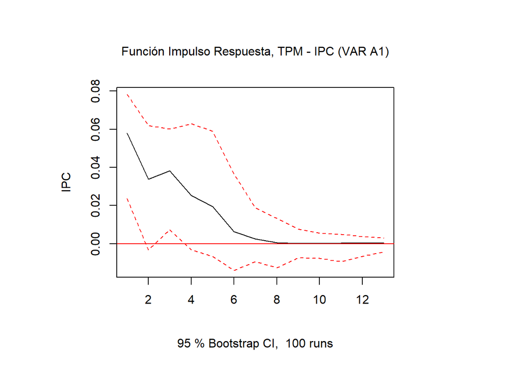

```r
plot(func_imp_resp1 , main="Función Impulso Respuesta, TPM - IPC (VAR A1)")
```

**Fin del ejercicio**